### Team Member 1: Giacomo Pirrone

### Student Number: S3658746

(I chose to not work in a team)

# Predicting Diamond Prices

## Introduction

The aim of this assignment is to predict the prices of diamonds using the diamonds data set from the ggplot2 R library.The dataset was sourced from this website https://www.kaggle.com/shivam2503/diamonds.

The report has been divided into the following parts:

- Overview which contains the information about the dataset and the features involved
- Data Preparation which involves data cleaning and data preparation order
- Data Exploration This involves creating the figures and then elaborating on the observations
- Statistical Modelling and Performance Evaluation This involves creating the full model and exploring figures involving the residual
- Summary and Conclusion A conclusion of the findings and indications that we observed while exploring this dataset

# Overview

## Project Objective

The project objective is to determine the price of a diamond from various features found in the diamond dataset sourced from the ggplot R library. By using various features such as the diamonds carat value and the depth of a diamond we can learn which values correspond with the increment or decerement in price value of an individual diamond.

## Target Feature

The target feature is **Price**. This is the price in US dollars (\$326 -- \\$18,823). The feature **Price** is continuous and numerical. Since our response variable is of these two characteristics our project will be on a regression problem.

## Descriptive Feature

- **Carat** weight of the diamond (0.2--5.01) (units not specified) *Continuous*
- **Cut** quality of the cut (Fair, Good, Very Good, Premium, Ideal) *Ordinal*
- **Color** diamond colour, from J(Worst) to D(Best) *Ordinal*
- **Clarity** a measurement of how clear the diamond is (I1 (worst), SI2, SI1, VS2, VS1, VVS2, VVS1, IF (best)) *Ordinal*
- **x** length in mm (0--10.74) *Continuous*
- **y** width in mm (0--58.9) *Continuous*
- **z** depth in mm (0--31.8) *Continuous*
- **Depth** total depth percentage = z / mean (x,y) = 2 * z / (x + y) (43--79)
- **Table** width of top of diamond relative to widest point (43--95) *Discrete*

Majority of the descriptive features above have intuitive titles which define themselves. The exceptions are descriptive features; x, y and z. Which represent "length", "width" and "depth" respectively. These features all relate to each individual diamonds size.

# Data Preparation

## Preliminaries

To initiate data preparation we must first import all common modules that are necessary for this project:

```python
import pandas as pd
import numpy as np
import matplotlib.pyplot as plt
import seaborn as sns
import statsmodels.api as sm
import statsmodels.formula.api as smf
import patsy
import warnings
###
warnings.filterwarnings('ignore')
###
%matplotlib inline
%config inlineBackend.figure_format = 'retina'
plt.style.use("ggplot")
```

I was unable to find a direct URL link to the dataset so I downloaded the .csv file and read it from my local files on my computer. Since descriptive features; x, y and z do not have a self explanatory name I will make sure to rename them when specifying the attribute names to make the column name understandable and intuitive. Because we are adding another row on top with all the new attribute names, all the old ones get pushed to the next row down so we delete the old row with the old column names. The original dataset also had a column with all the diamonds listed from the first to last numerically. When importing the data the indexing is already done for us so we remove the original index so we dont end up with two index columns.

```python
#Specifying the attribute names

attributeNames = [
    'Index No',
    'carat',
    'cut',
    'color',
    'clarity',
    'depth_total_percentage',
    'table',
    'price',
    'length_mm',
    'width_mm',
    'depth_mm'
]


#Read in data
df = pd.read_csv('Desktop\diamonds.csv',sep = ',', names = attributeNames, header = None)

#Drop unnecessary column and row
df = df.drop(columns=['Index No'])
df = df.drop([0])

#Display 10 randomly selected rows
df.sample(10, random_state=134)
```

|  | carat | cut | color | clarity | depth_total_percentage | table | price | length_mm | width_mm | depth_mm |
| --- | --- | --- | --- | --- | --- | --- | --- | --- | --- | --- |
| 20062 | 0.31 | Very Good | G | VS1 | 63 | 57 | 625 | 4.28 | 4.32 | 2.71 |
| 30052 | 0.41 | Premium | G | SI1 | 59.1 | 58 | 719 | 4.83 | 4.88 | 2.87 |
| 15258 | 1.01 | Good | G | VS2 | 62.7 | 60 | 6126 | 6.27 | 6.32 | 3.95 |
| 34650 | 0.31 | Ideal | E | VS2 | 62 | 55 | 872 | 4.37 | 4.34 | 2.7 |
| 34454 | 0.32 | Ideal | I | IF | 62.2 | 57 | 864 | 4.37 | 4.35 | 2.71 |
| 49845 | 0.71 | Premium | F | SI2 | 62.3 | 60 | 2169 | 5.7 | 5.67 | 3.54 |
| 28482 | 0.32 | Very Good | E | SI1 | 63.1 | 56 | 672 | 4.37 | 4.34 | 2.75 |
| 21553 | 2.01 | Premium | I | SI2 | 62.5 | 60 | 9658 | 8.04 | 7.95 | 5 |
| 47162 | 0.51 | Premium | G | VS1 | 59.6 | 58 | 1833 | 5.22 | 5.21 | 3.11 |
| 48620 | 0.7 | Very Good | I | SI1 | 63.5 | 59 | 1999 | 5.65 | 5.62 | 3.58 |

**You can download this dataset from this website:** https://www.kaggle.com/shivam2503/diamonds  
**Direct download link:** https://www.kaggle.com/shivam2503/diamonds/download

## Data Cleaning and Transformation

This step involves confirming that the feature types correspond to the descriptions defined in the original source.

```python
print(f"Dataset Shape: {df.shape}\n")
print("Data Types below: \n")
print(df.dtypes)
```

```
Dataset Shape: (53940, 10)

Data Types below:

carat                     object
cut                       object
color                     object
clarity                   object
depth_total_percentage    object
table                     object
price                     object
length_mm                 object
width_mm                  object
depth_mm                  object
dtype: object
```

**Note:** Oddly enough all the features appear as type object which indicates these are all of String value which is clearly incorrect. So we must convert these into their appropriate types.

```python
originalDataSet = pd.read_csv('Desktop\diamonds.csv')
print(originalDataSet.dtypes)
```

```
Unnamed: 0      int64
carat         float64
cut            object
color          object
clarity        object
depth         float64
table         float64
price           int64
x             float64
y             float64
z             float64
dtype: object
```

**Note:** These are the orginal datatypes for each column so we will change the datatypes in our cleaned up dataframe to match the orginal datatypes.

```python
df['carat'] = df.carat.astype(float)
df['depth_total_percentage'] = df.depth_total_percentage.astype(float)
df['table'] = df.table.astype(float)
df['length_mm'] = df.length_mm.astype(float)
df['width_mm'] = df.width_mm.astype(float)
df['depth_mm'] = df.depth_mm.astype(float)
df['price'] = df.price.astype(np.int64)
```

```python
print(f"Dataset Shape: {df.shape}\n")
print("Data Types below: \n")
print(df.dtypes)
```

```
Dataset Shape: (53940, 10)

Data Types below:

carat                     float64
cut                        object
color                      object
clarity                    object
depth_total_percentage    float64
table                     float64
price                       int64
length_mm                 float64
width_mm                  float64
depth_mm                  float64
dtype: object
```

**All the features now correspond to their appropriate datatype**

## Checking for Missing Values

```python
print(f"\nNumber of missing values for each feature:")
print(df.isnull().sum())
```

```
Number of missing values for each feature:
carat                     0
cut                       0
color                     0
clarity                   0
depth_total_percentage    0
table                     0
price                     0
length_mm                 0
width_mm                  0
depth_mm                  0
dtype: int64
```

all the features have a 0 next to it, indicating that all features seem to not have any missing values.

## Summary Statistics

```python
from IPython.display import display, HTML
display(HTML('<b>Table 1: Summary of continuous features</b>'))
df.describe(exclude='object')
```

**Table 1: Summary of continuous features**

|  | carat | depth_total_percentage | table | price | length_mm | width_mm | depth_mm |
| --- | --- | --- | --- | --- | --- | --- | --- |
| count | 53940.000000 | 53940.000000 | 53940.000000 | 53940.000000 | 53940.000000 | 53940.000000 | 53940.000000 |
| mean | 0.797940 | 61.749405 | 57.457184 | 3932.799722 | 5.731157 | 5.734526 | 3.538734 |
| std | 0.474011 | 1.432621 | 2.234491 | 3989.439738 | 1.121761 | 1.142135 | 0.705699 |
| min | 0.200000 | 43.000000 | 43.000000 | 326.000000 | 0.000000 | 0.000000 | 0.000000 |
| 25% | 0.400000 | 61.000000 | 56.000000 | 950.000000 | 4.710000 | 4.720000 | 2.910000 |
| 50% | 0.700000 | 61.800000 | 57.000000 | 2401.000000 | 5.700000 | 5.710000 | 3.530000 |
| 75% | 1.040000 | 62.500000 | 59.000000 | 5324.250000 | 6.540000 | 6.540000 | 4.040000 |
| max | 5.010000 | 79.000000 | 95.000000 | 18823.000000 | 10.740000 | 58.900000 | 31.800000 |

```python
display(HTML('<b>Table 2: Summary of categorical features</b>'))
df.describe(include = 'object')
```

**Table 2: Summary of categorical features**

|  | cut | color | clarity |
| --- | --- | --- | --- |
| count | 53940 | 53940 | 53940 |
| unique | 5 | 7 | 8 |
| top | Ideal | G | SI1 |
| freq | 21551 | 11292 | 13065 |

## Continuous Features

```python
df['price'].describe()
```

```
count    53940.000000
mean      3932.799722
std       3989.439738
min        326.000000
25%        950.000000
50%       2401.000000
75%       5324.250000
max      18823.000000
Name: price, dtype: float64
```

The range of **price** seems to be viable as the minimum and maximum price of the diamonds in this dataset are \$326 and \\$18823 respectively

Since **depth_total_percentage** is calculated by using **2 *z/(x + y)**. It makes sense to delete x,y and z as they are all represented by **depth_total_percentage** however this feature only describes the overall percentage of depth and will not directly tell us the size of the diamond. Additionally as there are many different types of shapes of diamonds and types of cuts we cannot directly fit x,y and z into a volume feature so we must keep them as they are individually.

## Fixing Column Names

All column names have no problems and are already in the correct format therefore we will keep them they way they already are.

## Categorical Features

We will examine all unique values for every categorical column. Categorical values are generally kept in the datatype of "Object", therefore we will determine the columns that are categorical by looking for "Object".

```python
categoricalColumns = df.columns[df.dtypes==object].tolist()

for col in categoricalColumns:
    print('Unique values for ' + col)
    print(df[col].unique())
    print('')
```

```
Unique values for cut
['Ideal' 'Premium' 'Good' 'Very Good' 'Fair']

Unique values for color
['E' 'I' 'J' 'H' 'F' 'G' 'D']

Unique values for clarity
['SI2' 'SI1' 'VS1' 'VS2' 'VVS2' 'VVS1' 'I1' 'IF']
```

# Data Exploration

## Univariate Visualisation

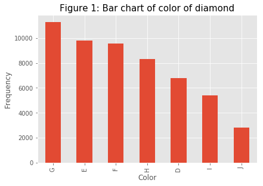

```python
ax = df['color'].value_counts().plot(kind='bar')
ax.set_xticklabels(ax.get_xticklabels(),rotation=90)

plt.tight_layout()
plt.title('Figure 1: Bar chart of color of diamond', fontsize=15)
plt.ylabel('Frequency')
plt.xlabel('Color')
plt.show();
```

As we can see in Figure 1 the most frequently occuring color is **G** . Followed by **E, F and H** having similar values. Generally speaking if an item of a certain specification is very abundant than this can lead to over saturation in the market and therefore affect the price in a negative manner. In the dataset it was established that **D** was the best color and **J** was the worst. Colors **D** and **J** are in the bottom three least frequent colors. This definitely makes sense as **D** would be quite hard to come by and **J** wouldn't be worth selling often as it is considered the least desirable. Another prediction could be that color **G** retains the median price value out of all the colors.

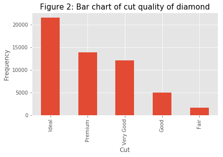

```python
ax = df['cut'].value_counts().plot(kind='bar')
ax.set_xticklabels(ax.get_xticklabels(),rotation=90)

plt.tight_layout()
plt.title('Figure 2: Bar chart of cut quality of diamond', fontsize=15)
plt.ylabel('Frequency')
plt.xlabel('Cut')
plt.show();
```

In Figure 2 we observe that **Ideal** seems to be the most frequent cut of diamonds. This makes sense as only a select few diamond cutters would be of such high skill to prepare a **Premium** cut or even a cut of similar quality. **Ideal** cuts would definitely be industry standard therfore they are the most abundant. **Fair** cuts are the least abundandt this is most likely due to the fact that diamonds are expensive and would only be handled by experts and not notive diamond cutters. My prediction is that Ideal cuts are associated with the median price of diamonds and Fair cuts share the lowest price while **Premium** and **Verry good** contain the upper limits of diamond prices.

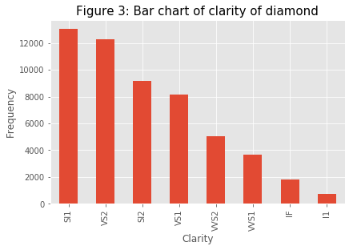

```python
ax = df['clarity'].value_counts().plot(kind='bar')
ax.set_xticklabels(ax.get_xticklabels(),rotation=90)

plt.tight_layout()
plt.title('Figure 3: Bar chart of clarity of diamond', fontsize=15)
plt.ylabel('Frequency')
plt.xlabel('Clarity')
plt.show();
```

In Figure 3 we observe that SI1 is the most abundant clarity value amongst all the diamonds in this dataset with VS2 following second in with a very similar value of frequency. I1 is the least abundant making up for only around 1000 out of all diamonds in the dataset. **IF** or flawless diamonds make up for just under 2000 appearances in the dataset. The low abundance in IF is self explanatory as flawless diamonds are hard to come by and are the rarest of all clarity values. An explanation for the low amounts of I1 could be that diamonds of this clarity aren't sought after due to their lacking quality in clarity therefore making them undesirable.

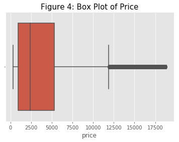

```python
sns.boxplot(df['price']).set_title('Figure 4: Box Plot of Price', fontsize = 15)
plt.show();
```

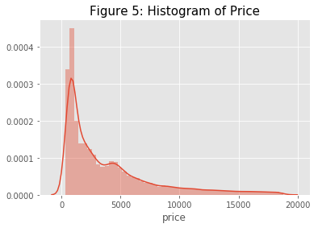

```python
sns.distplot(df['price'],kde=True).set_title('Figure 5: Histogram of Price',fontsize=15)
plt.show();
```

## Multivariate Visualisation

### Scatterplot of Numeric Features and Price

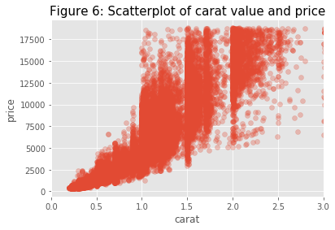

```python
plt.scatter(df['carat'],df['price'],alpha=0.3)
plt.title('Figure 6: Scatterplot of carat value and price',fontsize=15)
plt.xlim(0, 3)
plt.xlabel('carat')
plt.ylabel('price')
plt.show();
```

In Figure 6 it seems to be quite clear that there is a positive association with price and carat value. As the carat value increases so does the price. This is obvious as carat indicates the weight of a diamond and the heavier a diamond, generally it is larger in size and more dense therefore there is more diamond quantity. Higher amounts of diamond quantity clearly is associated with the increase of price.

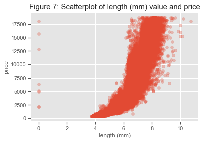

```python
plt.scatter(df['length_mm'],df['price'],alpha=0.3)
plt.title('Figure 7: Scatterplot of length (mm) value and price',fontsize=15)
plt.xlabel('length (mm)')
plt.ylabel('price')
plt.show();
```

In Figure 7 we observe that there is a positive association with length of the diamond and price. This is because the longer the diamond is, the more diamond quantity is present. More diamond quantity = higher price.

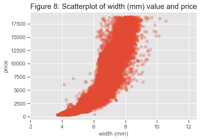

```python
plt.scatter(df['width_mm'],df['price'],alpha=0.3)
plt.title('Figure 8: Scatterplot of width (mm) value and price',fontsize=15)
plt.xlim(2, 12.5)
plt.xlabel('width (mm)')
plt.ylabel('price')
plt.show();
```

Figure 8 is similar to figure 7 whereby the larger the width the higher the price. This is for the same reason as above.

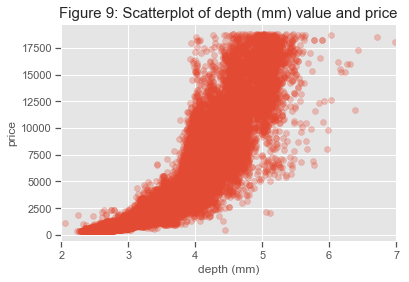

```python
plt.scatter(df['depth_mm'],df['price'],alpha=0.3)
plt.title('Figure 9: Scatterplot of depth (mm) value and price',fontsize=15)
plt.xlim(2, 7)
plt.xlabel('depth (mm)')
plt.ylabel('price')
plt.show();
```

Figure 9 displays the same results and features as Figures 7 and 8. I displayed all three length features to reassure that size increase of the diamond in all three dimensions will lead to an increase in price.

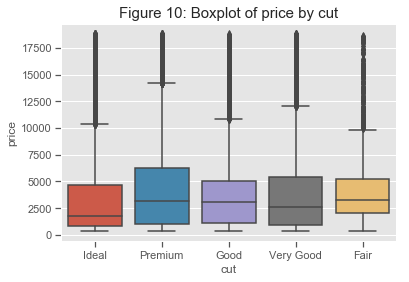

```python
sns.boxplot(df['cut'],df['price']);
plt.title('Figure 10: Boxplot of price by cut', fontsize = 15)
plt.show();
```

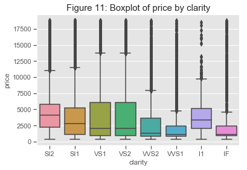

```python
sns.boxplot(df['clarity'],df['price']);
plt.title('Figure 11: Boxplot of price by clarity', fontsize = 15)
plt.show();
```

In Figure 11 what we observe isn't exactly what we would expect to see. The Flawless clarity value of **IF** has the lowest recorded price values out of all clarity values. This could be due to several reasons one being that flawless are rare and since we observed previously that size of diamonds increases the price, it would make sense that there aren't too many large flawless diamonds for sale therefore only smaller are sold meaning lower price. The highest recorded values for price belong to **VS1** and **VS2**. These are the middle values of clarity meaning more abundant meaning that larger diamonds are easier to come by. In conclusion this Figure doesn't really tell us much we may have to compare clarity and price with another value in order to get the information we need.

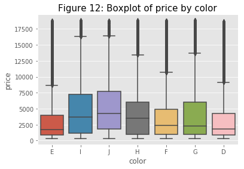

```python
sns.boxplot(df['color'],df['price']);
plt.title('Figure 12: Boxplot of price by color', fontsize = 15)
plt.show();
```

In Figure 12 we see another instance of what we might not expect to see. Color **J** which is considered the worst has the highest price values in comparison to the rest of the colors. Color **D** which is considered the best color has its price values towards the lower end alongside color **E**. Again we may need to compare these values with another feature to observe a more meaningful plot.

## Facet Plots

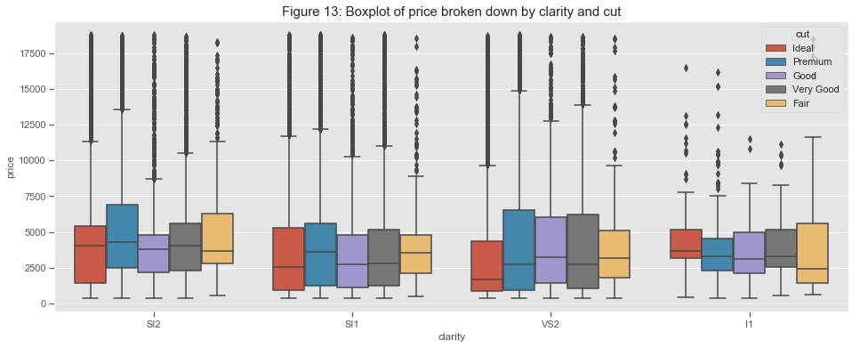

```python
plt.figure(figsize=(16,6))
low_clarity_mask = df['clarity'].isin(['I1', 'SI2', 'SI1', 'VS2'])
low_clarity = df[low_clarity_mask]
sns.boxplot(low_clarity['clarity'], low_clarity['price'], hue = low_clarity['cut'])
plt.title('Figure 13: Boxplot of price broken down by clarity and cut', fontsize = 15)
plt.show();
```

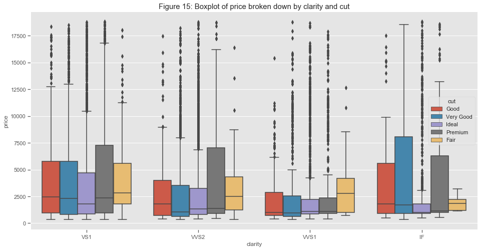

```python
plt.figure(figsize=(16,8))
high_clarity_mask = df['clarity'].isin(['VS1', 'VVS2', 'VVS1', 'IF'])
high_clarity = df[high_clarity_mask]
sns.boxplot(high_clarity['clarity'], high_clarity['price'], hue = high_clarity['cut'])
plt.title('Figure 15: Boxplot of price broken down by clarity and cut', fontsize = 15)
plt.show();
```

In Figure 15 we see an almost identical outcome in terms of trends. **Premium** cuts hold the highest price values besides for **flawless** diamonds. (Order VS1, VVS2, VVS1, IF) **VVS1** seems to be an outlier out of all the **Clarity** values as they contain the lowest price values, also the premium cut is the second lowest performing cut value in the group which is an oddball out of the rest of the clarity values once matched with a **Premium** cut. My guess is that these diamonds seem do not come in larger sizes often. This could be due to a multitude of reasons.

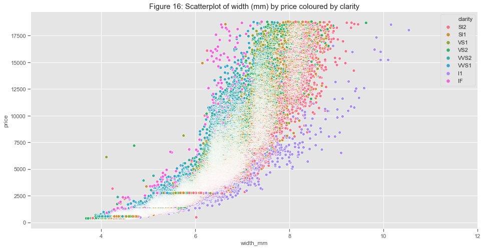

```python
plt.figure(figsize=(16,8))
# creating a scatterplot
sns.scatterplot(df['width_mm'], df['price'], hue = df['clarity'])
plt.title('Figure 16: Scatterplot of width (mm) by price coloured by clarity', fontsize = 15);
plt.xlim(2.5, 12)
plt.show();
```

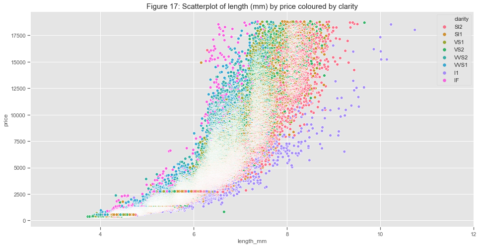

```python
plt.figure(figsize=(16,8))
# creating a scatterplot
sns.scatterplot(df['length_mm'], df['price'], hue = df['clarity'])
plt.title('Figure 17: Scatterplot of length (mm) by price coloured by clarity', fontsize = 15);
plt.xlim(2.5, 12)
plt.show();
```

Figure 17 provides an almost identical resulted plot to figure 16 and this is exactly what we wanted to see. As length increases with price the quality of the diamond clarity will drop.

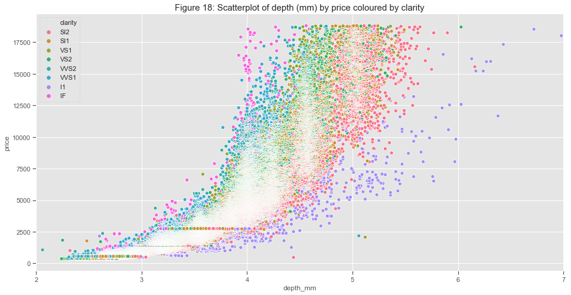

```python
plt.figure(figsize=(16,8))
# creating a scatterplot
sns.scatterplot(df['depth_mm'], df['price'], hue = df['clarity'])
plt.title('Figure 18: Scatterplot of depth (mm) by price coloured by clarity', fontsize = 15);
plt.xlim(2, 7)
plt.show();
```

Figure 18 solidified our findings even further with the plot showing a strikingly similar result. Size of a diamond price will increase the price of an individual diamond. Diamonds with higher clarity values require smaller sizes to reach higher prices in comparison to lower quality clarity diamonds.

# Statistical Modelling and Performance Evaluation

## Full Model

I will start by placing a multiple linear regression that predicts **price** using all the features in this dataset. This is also known as the Full Model. First step: we view the clean data.

```python
df.head()
```

|  | carat | cut | color | clarity | depth_total_percentage | table | price | length_mm | width_mm | depth_mm |
| --- | --- | --- | --- | --- | --- | --- | --- | --- | --- | --- |
| 1 | 0.23 | Ideal | E | SI2 | 61.5 | 55.0 | 326 | 3.95 | 3.98 | 2.43 |
| 2 | 0.21 | Premium | E | SI1 | 59.8 | 61.0 | 326 | 3.89 | 3.84 | 2.31 |
| 3 | 0.23 | Good | E | VS1 | 56.9 | 65.0 | 327 | 4.05 | 4.07 | 2.31 |
| 4 | 0.29 | Premium | I | VS2 | 62.4 | 58.0 | 334 | 4.20 | 4.23 | 2.63 |
| 5 | 0.31 | Good | J | SI2 | 63.3 | 58.0 | 335 | 4.34 | 4.35 | 2.75 |

```python
formula_string_indep_vars = ' + '.join(df.drop(columns='price').columns)
formula_string = 'price ~ ' + formula_string_indep_vars
print('formula_string: ', formula_string)
```

```
formula_string:  price ~ carat + cut + color + clarity + depth_total_percentage + table + length_mm + width_mm + depth_mm
```

**formula_string** is compatible with Statsmodels module. One issue arrises however, this is that we can't perform automatic variable selection with this formula. Therefore we need to do is 'one-hot-encoding' of categorical features.

In the block of code displayed below we use **get_dummies()** function in **pandas** for one-hot-encoding of categorical features. After this we will construct a new string formula with these features.

```python
data_encoded = pd.get_dummies(df, drop_first=True)
data_encoded.head()
```

|  | carat | depth_total_percentage | table | price | length_mm | width_mm | depth_mm | cut_Good | cut_Ideal | cut_Premium | ... | color_H | color_I | color_J | clarity_IF | clarity_SI1 | clarity_SI2 | clarity_VS1 | clarity_VS2 | clarity_VVS1 | clarity_VVS2 |
| --- | --- | --- | --- | --- | --- | --- | --- | --- | --- | --- | --- | --- | --- | --- | --- | --- | --- | --- | --- | --- | --- |
| 1 | 0.23 | 61.5 | 55.0 | 326 | 3.95 | 3.98 | 2.43 | 0 | 1 | 0 | ... | 0 | 0 | 0 | 0 | 0 | 1 | 0 | 0 | 0 | 0 |
| 2 | 0.21 | 59.8 | 61.0 | 326 | 3.89 | 3.84 | 2.31 | 0 | 0 | 1 | ... | 0 | 0 | 0 | 0 | 1 | 0 | 0 | 0 | 0 | 0 |
| 3 | 0.23 | 56.9 | 65.0 | 327 | 4.05 | 4.07 | 2.31 | 1 | 0 | 0 | ... | 0 | 0 | 0 | 0 | 0 | 0 | 1 | 0 | 0 | 0 |
| 4 | 0.29 | 62.4 | 58.0 | 334 | 4.20 | 4.23 | 2.63 | 0 | 0 | 1 | ... | 0 | 1 | 0 | 0 | 0 | 0 | 0 | 1 | 0 | 0 |
| 5 | 0.31 | 63.3 | 58.0 | 335 | 4.34 | 4.35 | 2.75 | 1 | 0 | 0 | ... | 0 | 0 | 1 | 0 | 0 | 1 | 0 | 0 | 0 | 0 |

5 rows × 24 columns

```python
formula_string_indep_vars_encoded = ' + '.join(data_encoded.drop(columns='price').columns)
formula_string_encoded = 'price ~ ' + formula_string_indep_vars_encoded
print('formula_string_encoded: ', formula_string_encoded)
```

```
formula_string_encoded:  price ~ carat + depth_total_percentage + table + length_mm + width_mm + depth_mm + cut_Good + cut_Ideal + cut_Premium + cut_Very Good + color_E + color_F + color_G + color_H + color_I + color_J + clarity_IF + clarity_SI1 + clarity_SI2 + clarity_VS1 + clarity_VS2 + clarity_VV…
```

Too make this more interesting we will add two interaction terms to our full model. We will add the interaction **carat** with **length_mm** and **table** respectively.

```python
formula_string_encoded = formula_string_encoded + ' + length_mm:carat + table:carat'
print('formula_string_encoded: ', formula_string_encoded)
```

```
formula_string_encoded:  price ~ carat + depth_total_percentage + table + length_mm + width_mm + depth_mm + cut_Good + cut_Ideal + cut_Premium + cut_Very Good + color_E + color_F + color_G + color_H + color_I + color_J + clarity_IF + clarity_SI1 + clarity_SI2 + clarity_VS1 + clarity_VS2 + clarity_VV…
```

We have defined our statistical model formula in a python string. We will now fit an ordinary least squares model to our encoded date.

**Note:** I had to remove the feature cut_very_good as it was causing issues with sm.formula.ols

```python
formula_string_encoded = formula_string_encoded[:128] + '_' + formula_string_encoded[128:]
```

```python
formula_string_encoded = formula_string_encoded.replace(formula_string_encoded[129],"")
```

```python
print('formula_string_encoded: ', formula_string_encoded)
```

```
formula_string_encoded:  price~carat+depth_total_percentage+table+length_mm+width_mm+depth_mm+cut_Good+cut_Ideal+cut_Premium+cut_Very_Good+color_E+color_F+color_G+color_H+color_I+color_J+clarity_IF+clarity_SI1+clarity_SI2+clarity_VS1+clarity_VS2+clarity_VVS1+clarity_VVS2+length_mm:carat+table:carat
```

```python
formula_string_encoded = formula_string_encoded.replace(formula_string_encoded[99:113],"")
```

```python
model_full = sm.formula.ols(formula=formula_string_encoded, data=data_encoded)
###
model_full_fitted = model_full.fit()
###
print(model_full_fitted.summary())
```

```
                            OLS Regression Results
==============================================================================
Dep. Variable:                  price   R-squared:                       0.919
Model:                            OLS   Adj. R-squared:                  0.919
Method:                 Least Squares   F-statistic:                 2.564e+04
Date:                Wed, 23 Oct 2019   Prob (F-statistic):               0.00
Time:                        21:12:16   Log-Likelihood:            -4.5584e+05
No. Observations:               53940   AIC:                         9.117e+05
Df Residuals:                   53915   BIC:                         9.120e+05
Df Model:                          24
Covariance Type:            nonrobust
==========================================================================================
                             coef    std err          t      P>|t|      [0.025      0.975]
------------------------------------------------------------------------------------------
Intercept                971.6834    486.327      1.998      0.046      18.479    1924.887
carat                   1.485e+04    328.029     45.256      0.000    1.42e+04    1.55e+04
depth_total_percentage   -85.3041      4.702    -18.141      0.000     -94.521     -76.088
table                     25.8826      4.907      5.275      0.000      16.265      35.500
length_mm               -974.4530     38.978    -25.000      0.000   -1050.850    -898.056
width_mm                  29.5528     19.392      1.524      0.128      -8.455      67.561
depth_mm                 -57.4729     33.619     -1.710      0.087    -123.366       8.420
cut_Good                 -33.2847     19.032     -1.749      0.080     -70.588       4.019
cut_Ideal                161.4305     14.158     11.402      0.000     133.680     189.181
cut_Premium               97.8882     14.125      6.930      0.000      70.202     125.574
color_E                 -212.3289     17.935    -11.839      0.000    -247.481    -177.176
color_F                 -279.7293     18.136    -15.424      0.000    -315.276    -244.183
color_G                 -487.7192     17.760    -27.462      0.000    -522.529    -452.910
color_H                 -983.2884     18.878    -52.085      0.000   -1020.290    -946.286
color_I                -1463.8598     21.210    -69.016      0.000   -1505.432   -1422.287
color_J                -2370.9615     26.193    -90.519      0.000   -2422.300   -2319.623
clarity_IF              5505.8240     50.785    108.414      0.000    5406.285    5605.363
clarity_SI1             3813.4249     43.282     88.107      0.000    3728.592    3898.258
clarity_SI2             2841.3429     43.547     65.247      0.000    2755.990    2926.696
clarity_VS1             4723.7442     44.213    106.840      0.000    4637.086    4810.402
clarity_VS2             4415.9783     43.503    101.510      0.000    4330.712    4501.244
clarity_VVS1            5161.5927     46.815    110.256      0.000    5069.835    5253.350
clarity_VVS2            5099.5817     45.505    112.065      0.000    5010.391    5188.773
length_mm:carat           82.3886     17.284      4.767      0.000      48.512     116.265
table:carat              -76.4117      4.711    -16.221      0.000     -85.645     -67.179
==============================================================================
Omnibus:                    14037.337   Durbin-Watson:                   1.199
Prob(Omnibus):                  0.000   Jarque-Bera (JB):           639623.008
Skew:                           0.479   Prob(JB):                         0.00
Kurtosis:                      19.843   Cond. No.                     9.80e+03
==============================================================================

Warnings:
[1] Standard Errors assume that the covariance matrix of the errors is correctly specified.
[2] The condition number is large, 9.8e+03. This might indicate that there are
strong multicollinearity or other numerical problems.
```

we plot actual price values vs. predicted price values

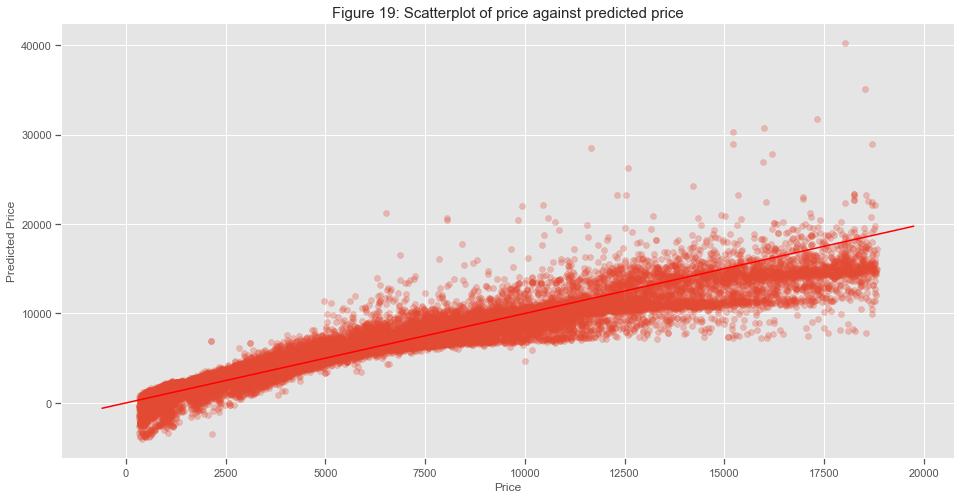

```python
plt.figure(figsize=(16,8))
def plot_line(axis, slope, intercept, **kargs):
    xmin, xmax = axis.get_xlim()
    plt.plot([xmin, xmax], [xmin*slope+intercept, xmax*slope+intercept], **kargs)


plt.scatter(data_encoded['price'], model_full_fitted.fittedvalues, alpha=0.3);
plot_line(axis=plt.gca(), slope=1, intercept=0, c="red");
plt.xlabel('Price');
plt.ylabel('Predicted Price');
plt.title('Figure 19: Scatterplot of price against predicted price', fontsize=15);
plt.show();
```

## Full Model Diagnostics Checks

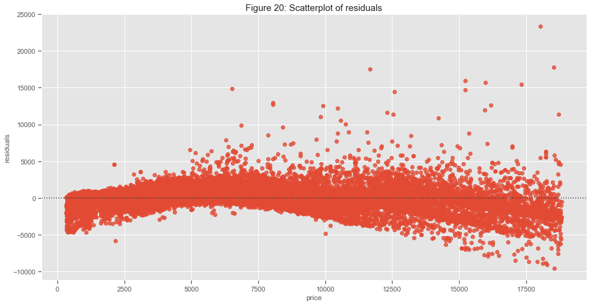

```python
plt.figure(figsize=(16,8))
sns.residplot(x=data_encoded['price'], y=model_full_fitted.fittedvalues);
plt.ylabel('residuals')
plt.title('Figure 20: Scatterplot of residuals', fontsize=15)
plt.show();
```

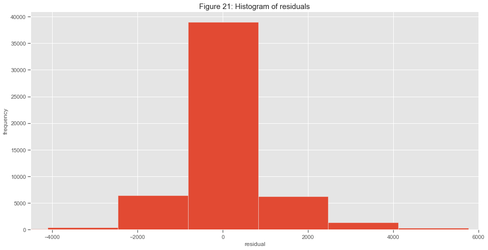

```python
plt.figure(figsize=(16,8))
residuals = data_encoded['price'] - model_full_fitted.fittedvalues
plt.hist(residuals, bins = 20);
plt.xlabel('residual');
plt.ylabel('frequency');
plt.xlim(-4500, 6000)
plt.title('Figure 21: Histogram of residuals', fontsize=15);
plt.show();
```

This histogram of residuals looks close to symmetric. These means that the residuals are close to normally distributed.

## Backwards Feature Selection

Using p-values we will now perform backwards feature selection

```python
## create the patsy model description from formula
patsy_description = patsy.ModelDesc.from_formula(formula_string_encoded)

# initialize feature-selected fit to full model
linreg_fit = model_full_fitted

# do backwards elimination using p-values
p_val_cutoff = 0.05

## WARNING 1: The code below assumes that the Intercept term is present in the model.
## WARNING 2: It will work only with main effects and two-way interactions, if any.

print('\nPerforming backwards feature selection using p-values:')

while True:

    # uncomment the line below if you would like to see the regression summary
    # in each step:
    ### print(linreg_fit.summary())

    pval_series = linreg_fit.pvalues.drop(labels='Intercept')
    pval_series = pval_series.sort_values(ascending=False)
    term = pval_series.index[0]
    pval = pval_series[0]
    if (pval < p_val_cutoff):
        break
    term_components = term.split(':')
    print(f'\nRemoving term "{term}" with p-value {pval:.4}')
    if (len(term_components) == 1): ## this is a main effect term
        patsy_description.rhs_termlist.remove(patsy.Term([patsy.EvalFactor(term_components[0])]))
    else: ## this is an interaction term
        patsy_description.rhs_termlist.remove(patsy.Term([patsy.EvalFactor(term_components[0]),
                                                        patsy.EvalFactor(term_components[1])]))

    linreg_fit = smf.ols(formula=patsy_description, data=data_encoded).fit()

###
## this is the clean fit after backwards elimination
model_reduced_fitted = smf.ols(formula = patsy_description, data = data_encoded).fit()
###

#########
print("\n***")
print(model_reduced_fitted.summary())
print("***")
print(f"Regression number of terms: {len(model_reduced_fitted.model.exog_names)}")
print(f"Regression F-distribution p-value: {model_reduced_fitted.f_pvalue:.4f}")
print(f"Regression R-squared: {model_reduced_fitted.rsquared:.4f}")
print(f"Regression Adjusted R-squared: {model_reduced_fitted.rsquared_adj:.4f}")
```

```
Performing backwards feature selection using p-values:

Removing term "width_mm" with p-value 0.1275

Removing term "depth_mm" with p-value 0.127

Removing term "cut_Good" with p-value 0.08476

***
                            OLS Regression Results
==============================================================================
Dep. Variable:                  price   R-squared:                       0.919
Model:                            OLS   Adj. R-squared:                  0.919
Method:                 Least Squares   F-statistic:                 2.930e+04
Date:                Thu, 24 Oct 2019   Prob (F-statistic):               0.00
Time:                        11:50:13   Log-Likelihood:            -4.5585e+05
No. Observations:               53940   AIC:                         9.117e+05
Df Residuals:                   53918   BIC:                         9.119e+05
Df Model:                          21
Covariance Type:            nonrobust
==========================================================================================
                             coef    std err          t      P>|t|      [0.025      0.975]
------------------------------------------------------------------------------------------
Intercept               1256.9599    470.557      2.671      0.008     334.664    2179.256
carat                   1.485e+04    326.897     45.441      0.000    1.42e+04    1.55e+04
depth_total_percentage   -89.4939      4.294    -20.843      0.000     -97.910     -81.078
table                     25.3588      4.903      5.172      0.000      15.749      34.969
length_mm               -981.4943     30.760    -31.908      0.000   -1041.784    -921.205
cut_Ideal                168.5009     13.537     12.447      0.000     141.968     195.034
cut_Premium              106.0060     13.223      8.017      0.000      80.089     131.923
color_E                 -212.2673     17.935    -11.835      0.000    -247.420    -177.114
color_F                 -279.6586     18.137    -15.420      0.000    -315.207    -244.111
color_G                 -487.4682     17.760    -27.447      0.000    -522.279    -452.658
color_H                 -982.7601     18.878    -52.058      0.000   -1019.761    -945.759
color_I                -1463.7752     21.211    -69.010      0.000   -1505.349   -1422.201
color_J                -2371.0863     26.194    -90.521      0.000   -2422.426   -2319.746
clarity_IF              5505.2960     50.772    108.431      0.000    5405.782    5604.810
clarity_SI1             3812.3918     43.268     88.111      0.000    3727.586    3897.198
clarity_SI2             2840.3577     43.535     65.244      0.000    2755.030    2925.686
clarity_VS1             4723.0419     44.199    106.859      0.000    4636.412    4809.672
clarity_VS2             4415.3784     43.493    101.519      0.000    4330.132    4500.625
clarity_VVS1            5161.4334     46.805    110.275      0.000    5069.695    5253.172
clarity_VVS2            5099.7091     45.496    112.092      0.000    5010.537    5188.881
length_mm:carat           82.3388     17.232      4.778      0.000      48.564     116.113
table:carat              -76.5091      4.704    -16.263      0.000     -85.730     -67.288
==============================================================================
Omnibus:                    14034.344   Durbin-Watson:                   1.199
Prob(Omnibus):                  0.000   Jarque-Bera (JB):           640436.965
Skew:                           0.479   Prob(JB):                         0.00
Kurtosis:                      19.853   Cond. No.                     9.45e+03
==============================================================================

Warnings:
[1] Standard Errors assume that the covariance matrix of the errors is correctly specified.
[2] The condition number is large, 9.45e+03. This might indicate that there are
strong multicollinearity or other numerical problems.
***
Regression number of terms: 22
Regression F-distribution p-value: 0.0000
Regression R-squared: 0.9194
Regression Adjusted R-squared: 0.9194
```

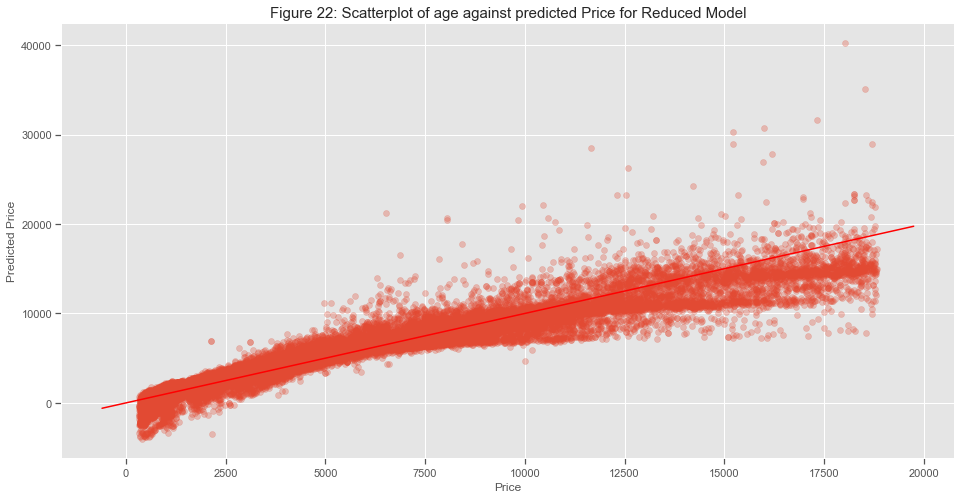

```python
plt.figure(figsize=(16,8))
# Creating scatter plot
plt.scatter(df['price'], model_reduced_fitted.fittedvalues, alpha=0.3);
plot_line(axis=plt.gca(), slope=1, intercept=0, c="red");
plt.xlabel('Price');
plt.ylabel('Predicted Price');
plt.title('Figure 22: Scatterplot of age against predicted Price for Reduced Model', fontsize=15);
plt.show();
```

## Reduced Model Diagnostic Checks

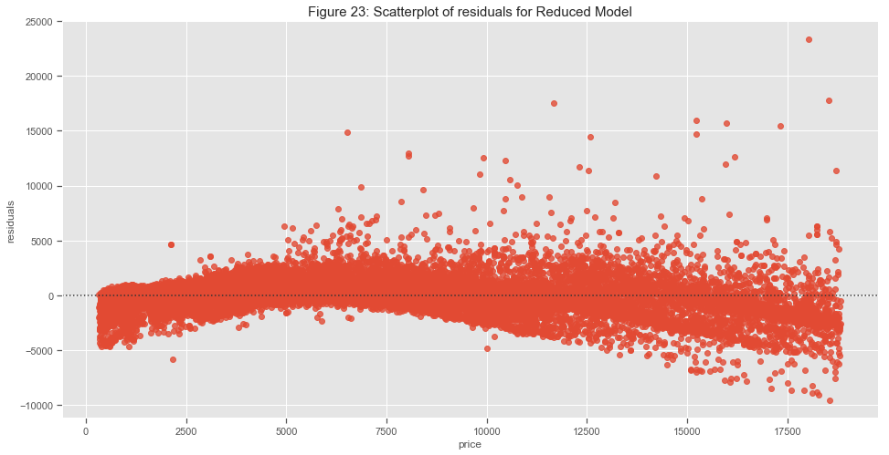

```python
plt.figure(figsize=(16,8))
sns.residplot(x=data_encoded['price'],  y=model_reduced_fitted.fittedvalues);
plt.ylabel('residuals')
plt.title('Figure 23: Scatterplot of residuals for Reduced Model', fontsize=15)
plt.show();
```

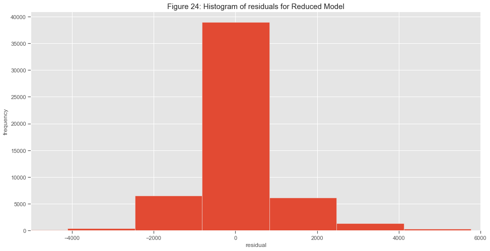

```python
plt.figure(figsize=(16,8))
residuals2 = data_encoded['price'] - model_reduced_fitted.fittedvalues
plt.hist(residuals2, bins = 20);
plt.xlim(-5000,6000)
plt.xlabel('residual');
plt.ylabel('frequency');
plt.title('Figure 24: Histogram of residuals for Reduced Model', fontsize = 15)
plt.show();
```

In Figure 24 we see that there is a almost symmetric histogram around zero. This tells us that the residuals relatively normally distrbuted.

# Summary and Conclusions

Although there are a few outliers in the dataset the regression model shows to predict price sufficiently. Out of all the figures produced it is safe to say that the main driving forces of diamond price are size (length, width and depth), clarity and cut. Diamonds of a lower clarity, cut or color tend to need to make up for its price in larger sizes this indicates lower quality diamonds price are more dependent on quantity of diamond, whereas higher quality diamonds make up for their price in craftsmanship of cut, clarity of the diamond and the rarity of color. A simple supply and demand is also present in this dataset whereby higher quality diamonds were less present and rarely reached the sizes of lower quality diamonds therefore they were less abundant, this is another reason as to why we observed higher prices in higher quality diamonds.

Outliers will always be present in datasets and many reasons could inform us as to why we observed outliers in this dataset. Diamonds can increase in price not only due to the features included in this dataset (clarity, size, carat, etc...) but also due to location of the diamond, history of the diamond and ethical sourcing of the diamond. Diamonds that perhaps come from a unique location could very well be another driving factor for price and if the diamonds are not sourced in an ethical manner this can also devalue the diamonds price.